# Replication of Ectoparasite Statistics

Before I move on I want to visualize the regression with the data to make sure the output makes sense.

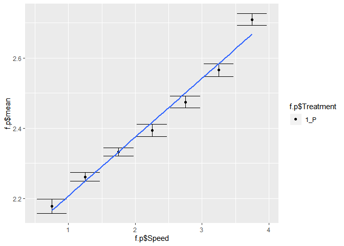

```r
f.p<-filter(f2,Treatment == "1_P")
j3<- ggplot(data=f.p,aes(x=f.p$Speed, y=f.p$mean))+ geom_point(aes(shape = f.p$Treatment))+ geom_errorbar(aes(ymin=mean-SE, ymax=mean+SE)) + geom_smooth(method = "lm", se=F)
j3
```

The line fits the points well, so my regression seems good.

```r
#For 2_UN
lm2<-lm(log10(MO2) ~ Speed, data=d[67:128,])
summary(lm2)
```

```
##
## Call:
## lm(formula = log10(MO2) ~ Speed, data = d[67:128, ])
##
## Residuals:
##      Min       1Q   Median       3Q      Max
## -0.27019 -0.04118  0.01564  0.05565  0.15366
##
## Coefficients:
##             Estimate Std. Error t value Pr(>|t|)
## (Intercept)  2.00840    0.06856  29.293  < 2e-16 ***
## Speed        0.14557    0.03790   3.841 0.000298 ***
## ---
## Signif. codes:  0 '***' 0.001 '**' 0.01 '*' 0.05 '.' 0.1 ' ' 1
##
## Residual standard error: 0.09234 on 60 degrees of freedom
## Multiple R-squared:  0.1973, Adjusted R-squared:  0.1839
## F-statistic: 14.75 on 1 and 60 DF,  p-value: 0.0002984
```

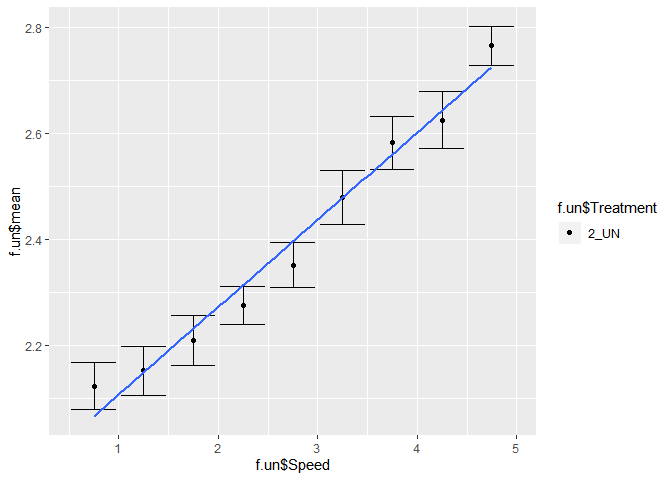

```r
f.un<-filter(f2,Treatment == "2_UN")
j4<- ggplot(data=f.un,aes(x=f.un$Speed, y=f.un$mean))+ geom_point(aes(shape = f.un$Treatment))+ geom_errorbar(aes(ymin=mean-SE, ymax=mean+SE)) + geom_smooth(method = "lm", se=F)
j4
```

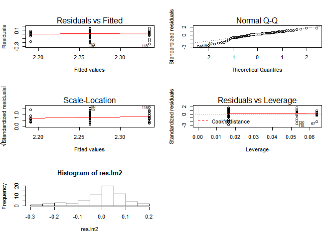

```r
par(mfrow = c(3, 2))
plot(lm2)
res.lm2<-resid(lm2)
hist(res.lm2)
```

The residuals are still not great here either.

```r
#For 3_FUN
lm3<-lm(log10(MO2) ~ Speed, data=d[129:197,])
summary(lm3)
```

```
##
## Call:
## lm(formula = log10(MO2) ~ Speed, data = d[129:197, ])
##
## Residuals:
##       Min        1Q    Median        3Q       Max
## -0.305377 -0.033044  0.001556  0.043421  0.190997
##
## Coefficients:
##             Estimate Std. Error t value Pr(>|t|)
## (Intercept)  2.04737    0.09554  21.430  < 2e-16 ***
## Speed        0.13129    0.03612   3.635  0.00054 ***
## ---
## Signif. codes:  0 '***' 0.001 '**' 0.01 '*' 0.05 '.' 0.1 ' ' 1
##
## Residual standard error: 0.09351 on 67 degrees of freedom
## Multiple R-squared:  0.1647, Adjusted R-squared:  0.1523
## F-statistic: 13.21 on 1 and 67 DF,  p-value: 0.0005401
```

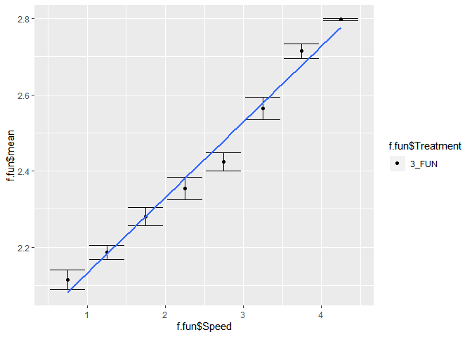

```r
f.fun<-filter(f2,Treatment == "3_FUN")
j5<- ggplot(data=f.fun,aes(x=f.fun$Speed, y=f.fun$mean))+ geom_point(aes(shape = f.fun$Treatment))+ geom_errorbar(aes(ymin=mean-SE, ymax=mean+SE)) + geom_smooth(method = "lm", se=F)
j5
```

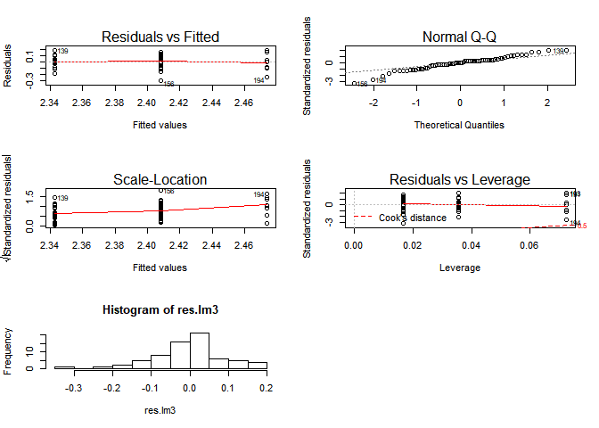

```r
par(mfrow = c(3, 2))
plot(lm3)
res.lm3<-resid(lm3)
hist(res.lm3)
```

```r
#For 4_REM
lm4<-lm(log10(MO2) ~ Speed, data=d[198:276,])
summary(lm4)
```

```
##
## Call:
## lm(formula = log10(MO2) ~ Speed, data = d[198:276, ])
##
## Residuals:
##       Min        1Q    Median        3Q       Max
## -0.275642 -0.052976  0.004681  0.068296  0.160064
##
## Coefficients:
##             Estimate Std. Error t value Pr(>|t|)
## (Intercept)  2.00238    0.08412  23.805  < 2e-16 ***
## Speed        0.16711    0.02254   7.415 1.35e-10 ***
## ---
## Signif. codes:  0 '***' 0.001 '**' 0.01 '*' 0.05 '.' 0.1 ' ' 1
##
## Residual standard error: 0.089 on 77 degrees of freedom
## Multiple R-squared:  0.4166, Adjusted R-squared:  0.409
## F-statistic: 54.98 on 1 and 77 DF,  p-value: 1.351e-10
```

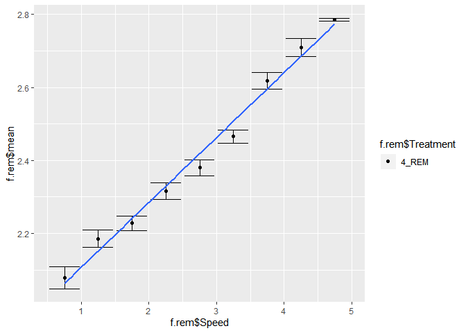

```r
f.rem<-filter(f2,Treatment == "4_REM")
j6<- ggplot(data=f.rem,aes(x=f.rem$Speed, y=f.rem$mean))+ geom_point(aes(shape = f.rem$Treatment))+ geom_errorbar(aes(ymin=mean-SE, ymax=mean+SE)) + geom_smooth(method = "lm", se=F)
j6
```

This has a log(MO2)=2.002+0.167U as compared to the paper’s 1.94+0.17U. All the significance numbers look good here as well.

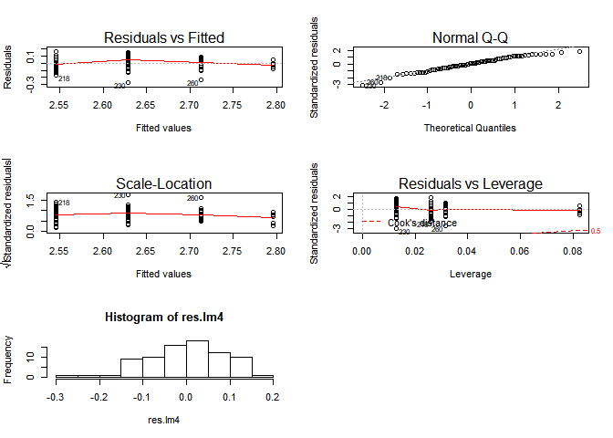

```r
par(mfrow = c(3, 2))
plot(lm4)
res.lm4<-resid(lm4)
hist(res.lm4)
```

The residuals aren’t great.

Now that all the regressions have been run and I have made sure they are all set, I am going to re-do Fig 2 with the data they said that they used.

First I start with the graph I made with all the means and se

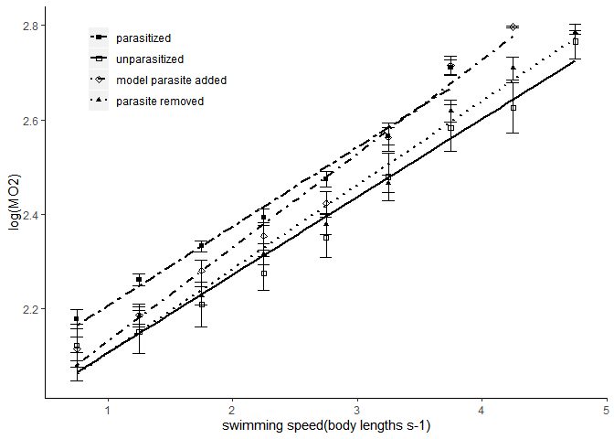

```r
j7<- ggplot(data=f2,aes(x=f2$Speed, y=f2$mean, shape=Treatment,line=Treatment ))+ geom_point(aes(shape = Treatment))
#I changed the width of the error bars to be smaller
j7<-j7+ geom_errorbar(aes(ymin=mean-SE, ymax=mean+SE), width=.1)
#This line changes the shapes used for each variable and the names associated with them
j7<- j7+ scale_shape_manual(values=c(15, 0,5, 17),labels=c("parasitized","unparasitized","model parasite added","parasite removed"))
#This line adds the regressions
j7<- j7+ geom_smooth(method="lm", se=F, aes(linetype=Treatment), color="black")
#These lines all deal with formatting
j7<- j7+ scale_linetype_manual(values=c("twodash","solid","dotdash","dotted"),labels=c("parasitized","unparasitized","model parasite added","parasite removed"))+scale_y_continuous(name= "log(MO2)")+scale_x_continuous(name="swimming speed(body lengths s-1)")+theme(legend.position = c(0.2,0.85), legend.box = "vertical",legend.title = element_blank(), panel.grid.major = element_blank(), panel.grid.minor = element_blank(), panel.background = element_blank(), axis.line = element_line(color="black"))
j7
```

This figure matches pretty closely with the original, as the small changes in the regression are minor.

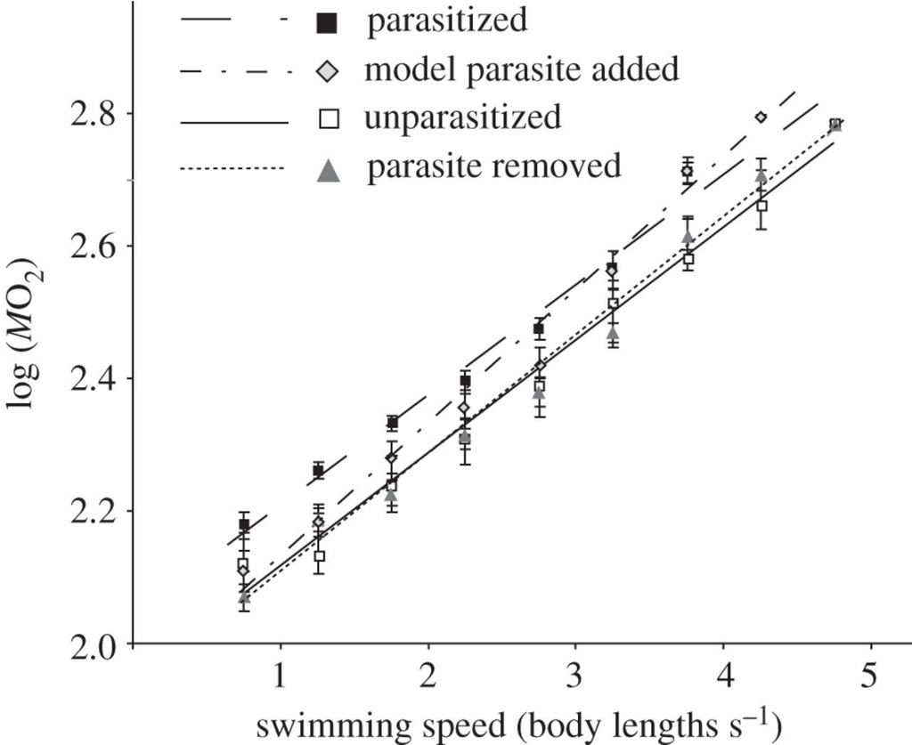

# Discussion

I found a few issues with this paper. The first was something that an editor should have fixed, which was the difference between the axis and legend labels in Fig. 1a. The graph matched the legend, and all their statistics match.

For many of the tests I ran, there was a slight difference between my calculations and the paper. They did not tend to affect the significance of the tests, but some of there were relatively large. Because of that, along with the fact that my MMR/SMR graph seems to have a discrepancy, and that the df freedom were different between the paper and me, it is likely that they removed outliers from the data before they used it. The paper, however, didn’t mention this.

The data did show a difference between the Parasitized group and everything else. It had a higher SMR and lower AS, meaning that the largest contributor to the Parasitized group being different was its standard metabolic rate. There didn’t seem to be a significant difference in the logarithmic oxygen consumption curves between treatments. I think it is likely that neither of the alternate hypothesis has a difference on their own. I think that this points to there being a additive effect between the two added stressors.